# Comportamiento del consumo de oxígeno y disponibilidad de camas en los hospitales del Perú entre los meses de marzo y septiembre del 2021

### Modelo 1: Modelo binomial

Decidimos optar por este modelo ya que nos permitía simular una situación real en la cual se encontraron muchos peruanos durante la pandemia del Covid-19 al ir de hospital en hospital buscando cilindros de oxígeno, cuya demanda estaba por los cielos. Así, establecemos nuestra variable aleatoria discreta:

X<sub>1</sub> : El hospital tiene más de x cilindros de oxígeno llenos al iniciar el día

```r
VarAleat1<- Oxigeno %>%  filter(CIL_NU_CIL_LLEN_INI_DU24>100)
prob1<-nrow(VarAleat1)/nrow(Oxigeno)
prob1
```

```
## [1] 0.1225492
```

Habiendo calculado el porcentaje de hospitales que cuentan con más de 100 cilindros llenos al iniciar el día (X<sub>1</sub> = 100), podemos hallar la probabilidad de que una persona, habiendo visitado 10 hospitales, encuentre uno que satisfaga lo mencionado: que cuente con más de 100 cilindros por día.

$$P\left(X=x\right)=\begin{pmatrix}n\\
x\end{pmatrix}p^x\left(1-p\right)^{n-x}$$
donde en este caso: * **x** = 1 * **n** = 10 * **p** = 0.1225

```r
dbinom(1, 10, prob1)
```

```
## [1] 0.3778466
```

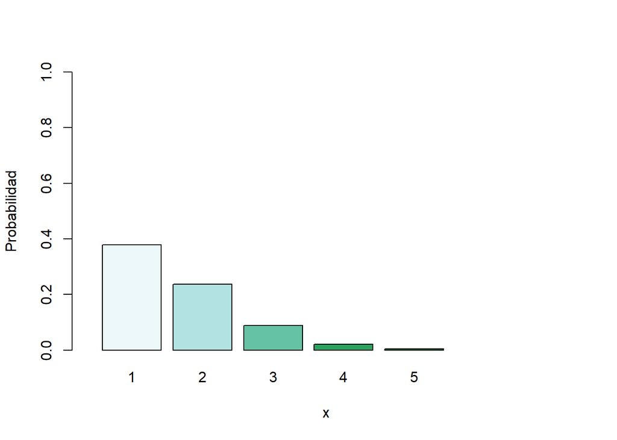

```r
barplot(dbinom(c(1:5), 10, prob1), ylim = c(0, 1), xlim = c(0, 8), ylab = "Probabilidad", names.arg = c(1:5), xlab = "x", col=brewer.pal(n=5, name = "BuGn"))
```

La probabilidad de que tras visitar 10 hospitales uno cuente con más de 100 cilindros llenos (
$$p$$
) es relativamente alta (37.78%). Sin embargo, lo que muchas veces ocurre en realidad es que se necesita más de un hospital que cumpla la condición ya que el primero que encontremos puede estar lleno (algo visto muy frecuentemente durante las primeras olas de COVID-19). Para este caso, como se observa en la gráfica, esta probabilidad irá disminuyendo a medida que requiramos encontrar más hospitales que cumplan con lo establecido.

Resulta importante mencionar que en la situación hipotética presentada se realizaron algunas suposiciones que no necesariamente se cumplen en realidad. Primero, no todos los eventos son equiprobables: algunos hospitales son más recurridos que otros. Además, el parámetro usado (100 cilindros llenos al iniciar el día) puede resultar tanto un número alto para algunas regiones como uno bajo para muchas otras. Por otro lado, bajo este modelo el individuo seguirá visitando 10 hospitales aún si es que ya encontró lo que busca anteriormente.